CAEL VESPER / SCHEDA DA TAVOLOD&D 2024 · LIVELLO 2

Il Cartografo del Cielo Morto

# Cael Vesper

**Druido 2 · Umano · Guida**  
Ordine: Magician · Il Dominio Oscuro  
Circolo delle Stelle: dal 3°, non ancora attivo.

«Non serve credere alle stelle.  
Serve sapere dove puntare.»

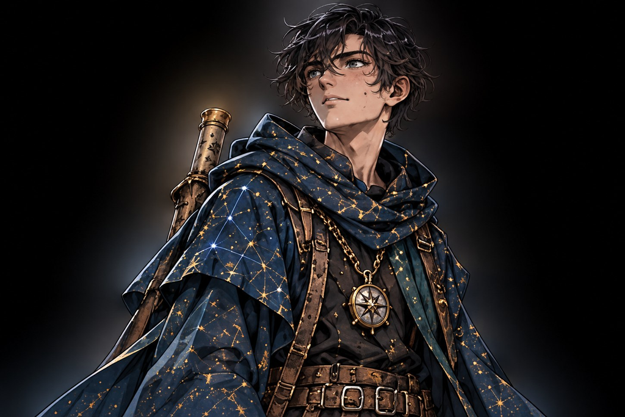

CA**16**14 senza scudo

PF massimi**19***attuali _____

Iniziativa**+5**DES + Alert

Velocità**9 m**30 piedi

Perc. passiva**16**Percezione +6

Competenza**+2**livello 2

FOR 10**+0**TS +0

DES 16**+3**TS +3

COS 17**+3**TS +3

INT 10**+0**TS +2 •

SAG 18**+4**TS +6 •

CAR 10**+0**TS +0

Abilità e competenze

Percezione •**+6**

Natura •**+6**

Furtività •**+5**

Sopravvivenza •**+6**

Indagare •**+2**

Arcana**+4**

Cartografia **+6 (SAG)** · Erboristeria **+2 (INT)**  
• = competente. Magician già incluso in Natura e Arcana.  
TS e classe: pp. 78–80; Guida p. 181; Umano p. 194.

**Lingue:** Comune, Druidico; altre da scegliere.  
**Addestramento:** armi semplici, armature leggere, scudi.

Risorse · compila alla sessione

**Slot di 1°**

**Forma Selvatica**

**Goodberry senza slot**

**Ispirazione Eroica**

Slot e Goodberry: riposo lungo. Forma Selvatica: 1 uso al breve, tutti al lungo (pp. 79–80, 201).  
Dadi vita **2d8** · PF temporanei ____ · Esaustione ____  
*19 PF a incremento fisso: da confermare con il DM.

Capacità in un colpo d’occhio

**Forma Selvatica · 1 AB** — 2 usi, dura 1 h; GS ≤ 1/4, niente volo. Mantieni i tuoi PF, ottieni 2 PF temporanei; non lanci incantesimi. 4 forme da scegliere. p. 80

**Wild Companion · 1 A Magia** — spendi 1 slot o 1 uso di Forma Selvatica: famiglio Fatato senza materiali. Scompare al riposo lungo. Forma da scegliere. p. 81

**Alert** — iniziativa +5 già calcolata; dopo il tiro puoi scambiarla con un alleato consenziente. Nessuno dei due deve essere Incapacitated. p. 200

**Umano** — Ispirazione Eroica dopo il riposo lungo: ritira un dado appena tirato, usando il nuovo risultato. pp. 194, 368

Attacchi con le armi

| Arma / configurazione | Attacco | Danno | Portata / nota |
| --- | --- | --- | --- |
| Bastone con Shillelagh* | **+6** | **1d8+4** | Mischia; forza o contundente |
| Bastone senza incantesimo | +2 | 1d6 | 1d8 a due mani; contundente |
| Falcetto | +2 | 1d4 | Mischia; tagliente, non Finesse |
| Arco corto | +5 | 1d6+3 | 24/96 m; due mani, no scudo |

Armi: pp. 215, 225. Cuoio + scudo: p. 219. Nessuna maestria d’arma attiva. *Formalizzare il bastone-focus come Quarterstaff; non è un nuovo acquisto.

**Concentrazione standard: +3**  
TS COS quando subisci danni: CD max(10, metà danni arrotondata per difetto), massimo 30. Un solo effetto. p. 363

**Variante di campagna: +7**  
Due effetti: CD minima 20; fallimento = perdi tutti. Non è il TS COS ordinario. In forma animale ricalcola la COS.

CAEL VESPER / INCANTESIMID&D 2024 · LIVELLO 2

## Incantesimi

**Attacco magico +6 · CD 14 · SAG +4** · 3 slot di 1° · 5 preparati ordinari

Starry Wisp

Trucchetto di classe

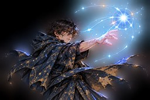

1 A · 18 m · creatura o oggetto

+6 contro CA → 1d8 radiante

Colpito: luce fioca 3 m e niente Invisible fino alla fine del tuo prossimo turno.

Istantaneo · V, S  
Nessuno slot · **PHB24 p. 320 (EN)**

Produce Flame

Trucchetto di classe

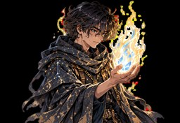

1 AB crea · 1 A Magia attacca · Personale; attacco 18 m

+6 contro CA → 1d8 fuoco

Creatura o oggetto. Attaccare non termina l’effetto. Luce intensa 6 m + fioca 6 m.

10 min · no concentrazione · V, S  
Nessuno slot · **PHB24 p. 308 (EN)**

Druidcraft

Magic Initiate · trucchetto

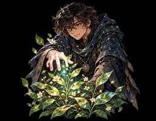

1 A · 9 m

Nessun tiro → Piccoli effetti naturali

Meteo, sbocciare, effetti innocui, accendere/spegnere fuochi. *Segnale meteo: 1 round.

Istantaneo* · V, S  
Nessuno slot · **PHB24 p. 266 (EN)**

Shillelagh

Magic Initiate · trucchetto

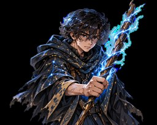

1 AB potenzia · 1 A Attaccare · Personale · arma impugnata

+6 contro CA → 1d8+4 forza o contundente

Solo Club/Quarterstaff. Finisce se lasci l’arma. Idoneità del focus da formalizzare.

1 min · no concentrazione · V, S, M  
Nessuno slot · **PHB24 p. 316 (EN)**

Healing Word

Preparato · 1° livello

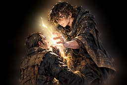

1 AB · 18 m · una creatura visibile

Nessun tiro → Cura 2d4+4 PF

Devi vedere il bersaglio; non serve contatto.

Istantaneo · V  
1 slot di 1° · **PHB24 p. 284 (EN)**

Cure Wounds

Preparato · 1° livello

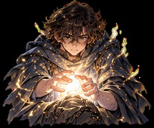

1 A · Contatto · una creatura

Nessun tiro → Cura 2d8+4 PF

Contatto consegnabile dal famiglio: entro 30 m da te, con la sua reazione.

Istantaneo · V, S  
1 slot di 1° · **PHB24 p. 259 (EN)**

Entangle

Preparato · 1° livello

[figure not shown]

1 A · 27 m · quadrato 6 m sul terreno

TS FOR CD 14 → Trattenuto + terreno difficile

TS iniziale, anche alleati (non Cael). Fuga: 1 A, prova FOR (Atletica) CD 14.

CONC · fino a 1 min · V, S  
1 slot di 1° · **PHB24 p. 268 (EN)**

Faerie Fire

Preparato · 1° livello

[figure not shown]

1 A · 18 m · cubo di 6 m

TS DES CD 14 → Vantaggio contro gli influenzati

Vantaggio se vedi il bersaglio; niente Invisible. Luce fioca 3 m. Anche alleati.

CONC · fino a 1 min · V  
1 slot di 1° · **PHB24 p. 271 (EN)**

Thunderwave

Preparato · 1° livello

[figure not shown]

1 A · Cubo di 4,5 m che origina da te

TS COS CD 14 → 2d8 tuono + spinta 3 m

Successo: metà danni, niente spinta. Anche alleati; spinge oggetti liberi. Boato 90 m.

Istantaneo · V, S  
1 slot di 1° · **PHB24 p. 334 (EN)**

Goodberry

Sempre preparato · Magic Initiate

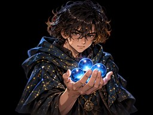

1 A crea · 1 AB mangia · 10 bacche nella tua mano*

Nessun tiro → 1 PF + nutrimento / bacca

Una bacca nutre per un giorno. *Gittata da confermare. Non include imboccare incoscienti.

24 h · V, S, M  
1 gratis / riposo lungo o 1 slot · **PHB24 p. 280 (EN)**

Speak with Animals

Sempre preparato · Druidic

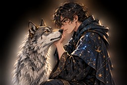

1 A · rituale: +10 min · Personale

Nessun tiro → Comprendi e parli con le Bestie

Comunicazione, non controllo. Solo creature di tipo Bestia.

10 min · no concentrazione · V, S  
1 slot; rituale senza slot · **PHB24 p. 318 (EN)**

Guidance

PROPOSTA · Magician

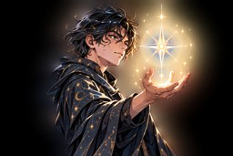

1 A · Contatto · creatura consenziente

Nessun tiro → +1d4 alle prove di un’abilità scelta

Ogni prova dell’abilità scelta; non attacchi o TS. Scelta da confermare.

CONC · fino a 1 min · V, S  
Nessuno slot · **PHB24 p. 282 (EN)**

**A** azione · **AB** azione bonus · **TS** tiro salvezza · **CONC** concentrazione · **V/S/M** verbale/somatica/materiale.  
**Trattenuto:** velocità 0; suoi attacchi e TS DES con svantaggio, attacchi contro di lui con vantaggio (p. 373).  
**Luce viva contro il Miasma:** da chiarire con il DM. Non basta che un effetto emetta luce.